# Assignment 3 - Instrumental Variables and Regression Discontinuity Designs

219744

September 19, 2023 | 12:08:56 | CEST

### General guidelines

- The expected submission output is an HTML file. Only HTML submissions will be graded.
- Include all your text-based answers inside the `<div class = "answer">` tags. Failing to do so will result in point deductions.
- Avoid printing unnecessary output, such as complete data frames. This will result in point deductions.
- Make sure that you explicitly point to the estimand you are being asked for. For instance, if your model reports estimates of multiple parameters, select or highlight the one(s) you are asked to report in the output, or report it separately in the answer box.
- Regression output should be presented in a report-worthy format, for example a well-formatted HTML table. There will be deductions if the results are presented as text console output (this includes `stargazer::stargazer(., type = "text")` and `texreg::texreg()`).
- Round to no more than two decimal points (e.g., 0.60 instead of 0.595).

### Task 1 - Bert and Ernie’s impact on letter recognition [9 points in total]

[figure not shown]

Suppose we want to estimate the effect of watching the educational television program **Sesame Street** on letter recognition for preschool children.

We considered implementing a randomized experiment where we assign children to the treatment (i.e., watching Sesame Street). As researchers, we realize that it is not possible, perhaps also unethical, for us to force children to watch a TV show or to refrain from watching it.

We decided to implement an encouragement design. The results are in the `sesame_df.dta` dataset:

- `id`: a numeric variable with the individual pre-schooler id
- `age`: a numeric variable with the age of the pre-schooler in months
- `encour`: a binary marker of the encouragement to watch Sesame Street
- `watched`: a binary marker of the treatment (the child watching Sesame Street)
- `reading_score`: a numeric variable with your outcome of interest, the reading score (based on a letter recognition task)

With these data, do the following:

1. Provide a naïve estimate of watching on letter recognition, ignoring the encouragement mechanism. Provide a technical (not causal) interpretation of the estimated coefficient. [1 point]

```r
sesame_df <- read_dta("sesame_df.dta")
model_1<- lm(reading_score ~ watched, data = sesame_df)
modelsummary(model_1,
  gof_omit = ".*",
 statistic = c("conf.int",
                           "s.e. = {std.error}",
                           "t = {statistic}",
                           "p = {p.value}"),stars = TRUE, output = "html")
```

|  | Model 1 |
| --- | --- |
| (Intercept) | 16.907*** |
|  | [13.610, 20.205] |
|  | s.e. = 1.674 |
|  | t = 10.100 |
|  | p = 0.000 |
| watched | 12.689*** |
|  | [8.943, 16.435] |
|  | s.e. = 1.902 |
|  | t = 6.673 |
|  | p = 0.000 |

+ p < 0.1, * p < 0.05, ** p < 0.01, *** p < 0.001

As the table above shows that if a kid watched sesame street there will be a significant and positive impact on their reading score by 12.689 units.

2. Illustrate visually the observed differences in the outcome of interest - in terms of the entire distributional form, the mean, and the median - between the `watched = 1` and the `watched = 0` groups. [2 points]

[figure not shown]

```r
med_readingsc <- sesame_df %>%
  group_by(watched) %>%
  summarize(median=median(reading_score))

mean_readingsc <- sesame_df %>%
  group_by(watched) %>%
  summarize(mean=mean(reading_score))

ggplot(sesame_df, aes(x = reading_score, fill = factor(watched))) +
  geom_density(alpha = 0.5) +
  scale_fill_manual(name = " ", # changes to fill dimension
                     values = c("#a7a8aa", "#cc0055"),
                     labels = c("Control", "Treatment")) +
geom_vline(data = med_readingsc, aes(xintercept = median,
                                       color = "#a7a8aa"),linetype = "longdash", size=0.8)+
  geom_vline(data = mean_readingsc, aes(xintercept = mean,
                                       color = "#cc0055" ),linetype = "longdash", size=0.8)+ scale_color_manual(
  values = c("#cc0055", "#a7a8aa"),
  labels = c("mean", "median")
)+
  theme_minimal() +
  theme(legend.position = "bottom") +
  labs(title = "Distribution of letter recognition for preschool children",
       x = "Reading score",
       y = "Density")
```

3. Discuss the assumptions needed for the experimental encouragement to work as an instrument for watching the show (not just generally, but applied to the specific case) and describe potential violations of these assumptions. [2 points]

The experimental encouragement in order to work as a instrument must follow this assumptions:relevant, meaning the encouragement must affect the willingness of a kid to watch sesame street; exogeneity/ignorability of the instrument, the encouragement must be independent of the reading score of a kid and any other potential treatment; exclusion/restriction, the encouragement only affect the reading score result of the kid through watching sesame street; and finally monotonicity which implies that every kid is affected in the same level by the encouragement(instrument) and if these hold the estimate among compliers will be consistent.

4. What do we know about non-compliance in the data? Provide descriptive evidence (table or plot) plus a short verbal description. [1 point]

```r
sesame_df %>% # your data frame
  janitor::tabyl(watched, encour) %>% # the two dimensions for the table (D, Z)
  janitor::adorn_totals(c("row", "col")) %>% # add totals for rows and cols
  knitr::kable() %>% # turn into a kable table for nice rendering in HTML
  kableExtra::kable_styling() %>%
  kableExtra::add_header_above(c("Watched sesame street", "encourage" = 2, ""))
```

| Watched sesame street watched | encourage 0 | encourage 1 | Total |
| --- | --- | --- | --- |
| 0 | 40 | 14 | 54 |
| 1 | 48 | 138 | 186 |
| Total | 88 | 152 | 240 |

The non-compliers in this table are much more less than compliers. It shows than two groups: always-taker and the never-takers, the first one are 48 kids and the other are 14 kids, that sum up to 62 kids (25,8%) that won´t do what they are told in the experiment environment.

5. Report a statistic showing whether the encouragement can or cannot be considered a strong instrument. [1 point]

```r
model_2<- lm(watched ~ encour, data = sesame_df)
 modelsummary(model_2,stars=TRUE, escape = FALSE, output="html")
```

|  | Model 1 |
| --- | --- |
| (Intercept) | 0.545*** |
|  | (0.041) |
| encour | 0.362*** |
|  | (0.051) |
| Num.Obs. | 240 |
| R2 | 0.175 |
| R2 Adj. | 0.171 |
| AIC | 221.8 |
| BIC | 232.2 |
| Log.Lik. | −107.884 |
| F | 50.464 |

+ p < 0.1, * p < 0.05, ** p < 0.01, *** p < 0.001

From the regression above , it is plausible to say that the encouragement is a strong instrument because the F-statistic is 50.464 which is greater than 10 conventionally consider by economist for the case of a single endogenous regressor to be considered a strong instrument.

6. Provide an estimate for the **Intent to Treat effect (ITT)** and give a brief substantive interpretation to the coefficients rendered [1 point]

```r
itt_model <- lm(reading_score ~ encour, data = sesame_df)

modelsummary(itt_model,
 statistic = c("conf.int","s.e. = {std.error}","p = {p.value}" ),stars = TRUE,output = "html")
```

|  | Model 1 |
| --- | --- |
| (Intercept) | 24.920*** |
|  | [22.121, 27.720] |
|  | s.e. = 1.421 |
|  | p = 0.000 |
| encour | 2.876 |
|  | [−0.642, 6.393] |
|  | s.e. = 1.786 |
|  | p = 0.109 |
| Num.Obs. | 240 |
| R2 | 0.011 |
| R2 Adj. | 0.007 |
| AIC | 1928.3 |
| BIC | 1938.8 |
| Log.Lik. | −961.160 |
| F | 2.593 |

+ p < 0.1, * p < 0.05, ** p < 0.01, *** p < 0.001

The regression sustain that the encouragement affect 2.876 units the reading score but doesn´t have a significant impact in the outcome ( reading score) because the p-value is greater than 0.05. Additionally, the R2 is very low, even though it could be consider as a strong instrument as it proved in e) section.

7. Provide an estimate for the **Local Average Treatment Effect (LATE)** and give a brief substantive interpretation to the coefficients rendered [1 point]

```r
late_model <- AER::ivreg(reading_score ~ watched | encour, data = sesame_df)
modelsummary(late_model,
 statistic = c("conf.int",
                           "s.e. = {std.error}",
                           "t = {statistic}",
                           "p = {p.value}"),stars = TRUE,output = "html")
```

|  | Model 1 |
| --- | --- |
| (Intercept) | 20.593*** |
|  | [13.421, 27.764] |
|  | s.e. = 3.659 |
|  | t = 5.628 |
|  | p = 0.000 |
| watched | 7.934+ |
|  | [−1.093, 16.961] |
|  | s.e. = 4.606 |
|  | t = 1.723 |
|  | p = 0.086 |
| Num.Obs. | 240 |
| R2 | 0.135 |
| R2 Adj. | 0.132 |

+ p < 0.1, * p < 0.05, ** p < 0.01, *** p < 0.001

### Task 2 - Effects of a pre- and post-natal health care policy [12 points in total]

The dataset `hospitals.tsv` provides data collected on women who gave birth at any one of several hospitals in disadvantaged neighborhoods in New York. These data are used to evaluate the effect of a government policy that makes available pre- and post-natal health care for pregnant women, new mothers, and their children, who meet certain income eligibility requirements. **To receive services, the income of these women has to have been below $20,000 at the time they gave birth**. The general question of interest is whether this program increases a measure of child health at age 3. Here is a short description of the data:

- `incomeR:` Reported household income in thousands
- `health:` A numeric health score
- `program:` A binary program marker

With these data, perform the following tasks:

1. Provide a visual check and a brief interpretation of what you see! Does it make sense to employ a sharp RD in this case? [1 point]

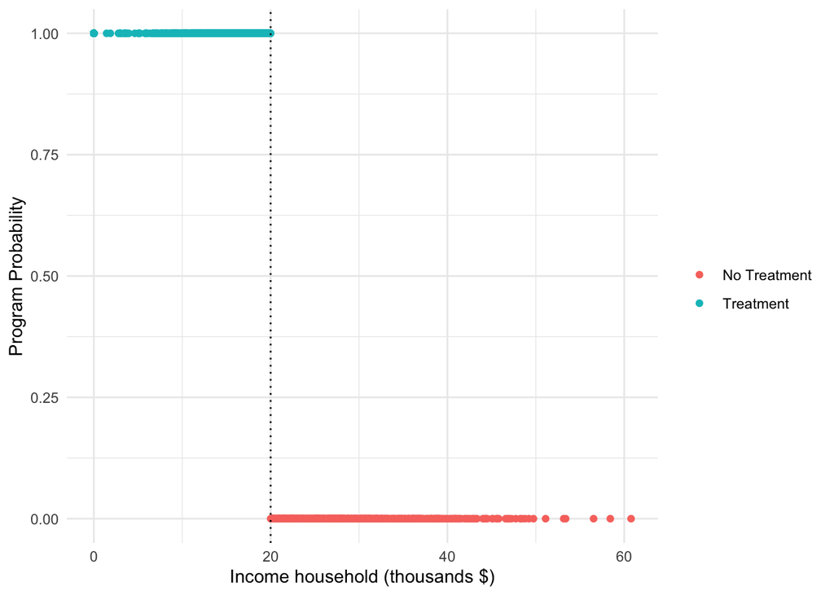

```r
hospitals <- read_tsv("hospitals.tsv", show_col_types = FALSE)
ggplot(hospitals, aes(x =incomeR ,
                 y = program,
                 color = factor(program))) +
  geom_point() +
  labs(x = "Income household (thousands $)",
       y = "Program Probability") +
  scale_color_discrete(name = " ",
                       labels = c("No Treatment ", "Treatment")) +
  geom_vline(xintercept = 20, linetype = "dotted") +
  theme_minimal()
```

From the graph above we can see that at the 20 thousand dollars threshold, the women are consider into the program which would make income household a viable forcing variable for a sharp-RDD set-up.

2. Create a scatterplot of reported income versus health status. Plot **treated** observations in **#ff990d (orange)** and **controls** in #a7a8aa (light gray). **Keep this convention for future plots in this task.** [1 point]

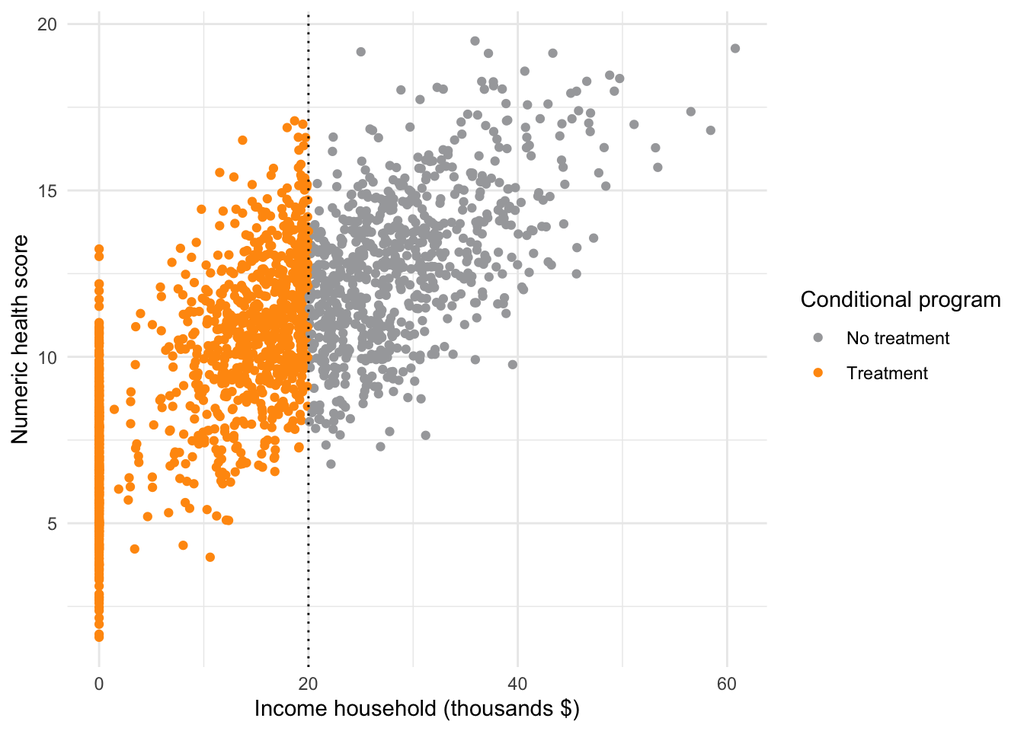

```r
ggplot(hospitals, aes(x =incomeR ,
                 y = health,
                 color = factor(program))) +
  geom_point() +
  labs(x = "Income household (thousands $)",
       y = "Numeric health score") +
   scale_color_manual(name="Conditional program",values=c("#a7a8aa", "#ff990d"),
                       labels = c("No treatment", "Treatment"))+
  geom_vline(xintercept = 20, linetype = "dotted") +
  theme_minimal()
```

From the graph above is possible to see that $20 thousand is in fact cutting off the distribution of the treatment. This would make household income a viable forcing variable for a sharp-RDD set-up as mention in letter a).

3. Calculate a naïve estimate of the effect of the program by running a regression of health on the indicator for program participation. What is the estimate, and why is it naïve? [1 point]

```r
naive_model <- lm(health ~ program , data = hospitals)
modelsummary(naive_model,
 statistic = c("conf.int",
                           "s.e. = {std.error}",
                           "p = {p.value}"),stars = TRUE,output = "html")
```

|  | Model 1 |
| --- | --- |
| (Intercept) | 12.813*** |
|  | [12.620, 13.006] |
|  | s.e. = 0.098 |
|  | p = 0.000 |
| program | −3.536*** |
|  | [−3.778, −3.293] |
|  | s.e. = 0.124 |
|  | p = 0.000 |
| Num.Obs. | 2000 |
| R2 | 0.290 |
| R2 Adj. | 0.290 |
| AIC | 9602.1 |
| BIC | 9618.9 |
| Log.Lik. | −4798.073 |
| F | 817.705 |

+ p < 0.1, * p < 0.05, ** p < 0.01, *** p < 0.001

The regression above show that being part of the program affect negatively and significative the numeric health score of the person, however this estimate is naive because it implies that the mean ignorability of treatment assignment assumption is fulfilled.

4. Cut down the dataset to a sample containing only the units within **± $2800** from the threshold, and then estimate the LATE at the threshold using a **linear model with common slopes** with `lm()`. Provide a plot in which you show the fitted curves and the underlying scatterplot of the data. **Interpret your estimate.** [2 points]

```r
attach(hospitals)
newhospital <- hospitals[ which(incomeR >=20-2.8 & incomeR <=20+2.8),]

linear_model <- lm(health ~ program + incomeR, data = newhospital)

modelsummary(linear_model,
 statistic = c("conf.int",  "s.e. = {std.error}",
                           "p = {p.value}"),stars = TRUE,output = "html")
```

|  | Model 1 |
| --- | --- |
| (Intercept) | 5.282* |
|  | [0.515, 10.048] |
|  | s.e. = 2.425 |
|  | p = 0.030 |
| program | 1.290*** |
|  | [0.606, 1.974] |
|  | s.e. = 0.348 |
|  | p = 0.000 |
| incomeR | 0.283* |
|  | [0.061, 0.504] |
|  | s.e. = 0.113 |
|  | p = 0.012 |
| Num.Obs. | 434 |
| R2 | 0.033 |
| R2 Adj. | 0.029 |
| AIC | 1795.2 |
| BIC | 1811.5 |
| Log.Lik. | −893.601 |
| F | 7.410 |

+ p < 0.1, * p < 0.05, ** p < 0.01, *** p < 0.001

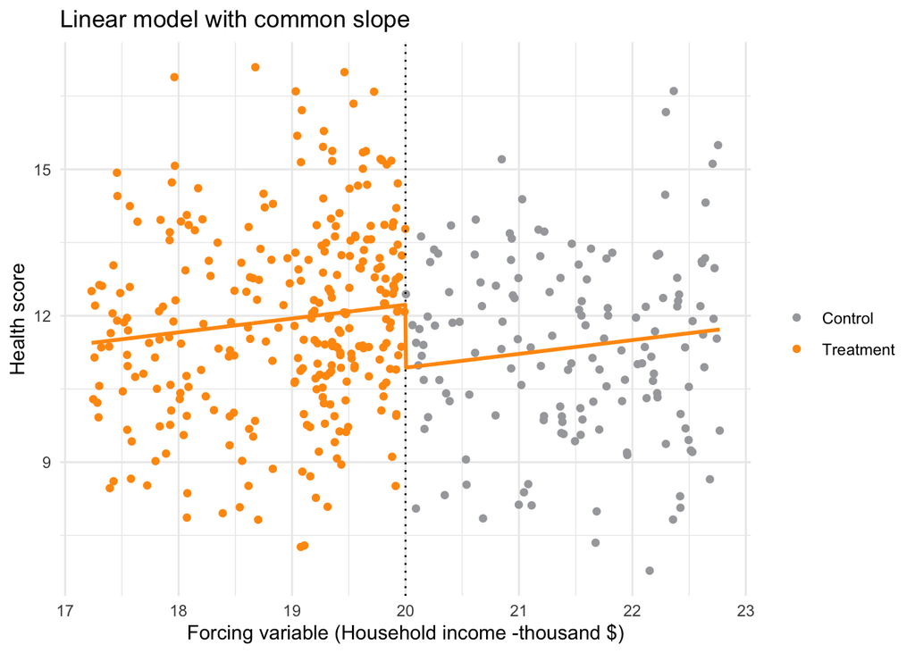

```r
newhospital$yhat <- predict(linear_model)

linear_plot <- newhospital %>% # for this plot make sure to put the df outside the
  ggplot(aes(x = incomeR,
             y = yhat, # notice here the predicted y
             col = factor(program))) +
  geom_point(aes(x = incomeR,
                 y = health ,# notice here the actual outcome
                 col = factor(program))) +
  geom_vline(xintercept = 20, linetype = "dotted") +
  labs(title = "Linear model with common slope",
       x = "Forcing variable (Household income -thousand $)",
       y = "Health score") +
  geom_line(data = newhospital[newhospital$program >= 0,],
            color = "#ff990d", # color lines
            size = 1) +
  geom_line(data = newhospital[newhospital$program < 0,],
            color = "#a7a8aa",# color lines
            size = 1) +
  scale_color_manual(name = "",
                     values = c("#a7a8aa", "#ff990d"),
                     labels = c("Control", "Treatment")) +
  theme_minimal()

linear_plot
```

In “Model 1” the first assumption that we take in consideration is that the effect of being part of the program does not depend on the forcing threshold of the household income. Considering this condition the result shows that we can expect 1.290 units increase in the health score for people with a household income below 20 thousand dollars. Moreover, for every thousand dollar extra the expected health score increase in 0.283 units.

5. Conduct the same analysis as in part (d) except that you now use a quadratic model with different model coefficients for the treated and control groups. **Interpret your estimate.** [2 points]

```r
quadratic_model <- lm(health ~ incomeR +
                  I(incomeR^2) +
                  program +
                  I(incomeR * program) +
                  I((incomeR^2) * program),
                data = newhospital)
modelsummary(quadratic_model,   gof_omit = ".*",
 statistic = c("conf.int",
                           "s.e. = {std.error}",
                           "t = {statistic}",
                           "p = {p.value}"),stars = TRUE,output = "html")
```

|  | Model 1 |
| --- | --- |
| (Intercept) | 150.091 |
|  | [−86.153, 386.335] |
|  | s.e. = 120.194 |
|  | t = 1.249 |
|  | p = 0.212 |
| incomeR | −13.012 |
|  | [−35.100, 9.075] |
|  | s.e. = 11.237 |
|  | t = −1.158 |
|  | p = 0.248 |
| I(incomeR^2) | 0.305 |
|  | [−0.211, 0.820] |
|  | s.e. = 0.262 |
|  | t = 1.161 |
|  | p = 0.246 |
| program | −59.829 |
|  | [−333.788, 214.130] |
|  | s.e. = 139.382 |
|  | t = −0.429 |
|  | p = 0.668 |
| I(incomeR * program) | 4.180 |
|  | [−22.450, 30.810] |
|  | s.e. = 13.549 |
|  | t = 0.309 |
|  | p = 0.758 |
| I((incomeR^2) * program) | −0.057 |
|  | [−0.709, 0.594] |
|  | s.e. = 0.331 |
|  | t = −0.172 |
|  | p = 0.863 |

+ p < 0.1, * p < 0.05, ** p < 0.01, *** p < 0.001

6. Now estimate, **with the full dataset**, the LATE at the threshold using a local linear regression with `rdrobust::rdrobust()`. Use the defaults (`kernel = "tri"` and `bwselect = mserd`). **Interpret your estimate.** [2 points]

```r
llr <- rdrobust::rdrobust(hospitals$health,
                          hospitals$incomeR,
                          c = 20,
                          kernel = "tri",
                          bwselect = "mserd",
                          p = 1)
```

```
[1] "Mass points detected in the running variable."
```

```r
summary(llr)
```

```
Call: rdrobust

Number of Obs.                 2000
BW type                       mserd
Kernel                   Triangular
VCE method                       NN

Number of Obs.                 1265          735
Eff. Number of Obs.             448          263
Order est. (p)                    1            1
Order bias  (q)                   2            2
BW est. (h)                   5.395        5.395
BW bias (b)                   8.298        8.298
rho (h/b)                     0.650        0.650
Unique Obs.                     766          735

=============================================================================
        Method     Coef. Std. Err.         z     P>|z|      [ 95% C.I. ]
=============================================================================
  Conventional    -1.192     0.265    -4.495     0.000    [-1.712 , -0.672]
        Robust         -         -    -3.986     0.000    [-1.855 , -0.632]
=============================================================================
```

Considering now the whole dataset, the result above tell us that that based on calculation that the result on the health score will be -1.192 units for the person whose household income is below 20 thousand.

7. A colleague now points out to you that some women may have incentives in these settings to misreport their actual income. Plot a histogram of reported income and look for anything that might support or refute such a claim. What assumption is called into question if women are truly misreporting in this manner? [2 points]

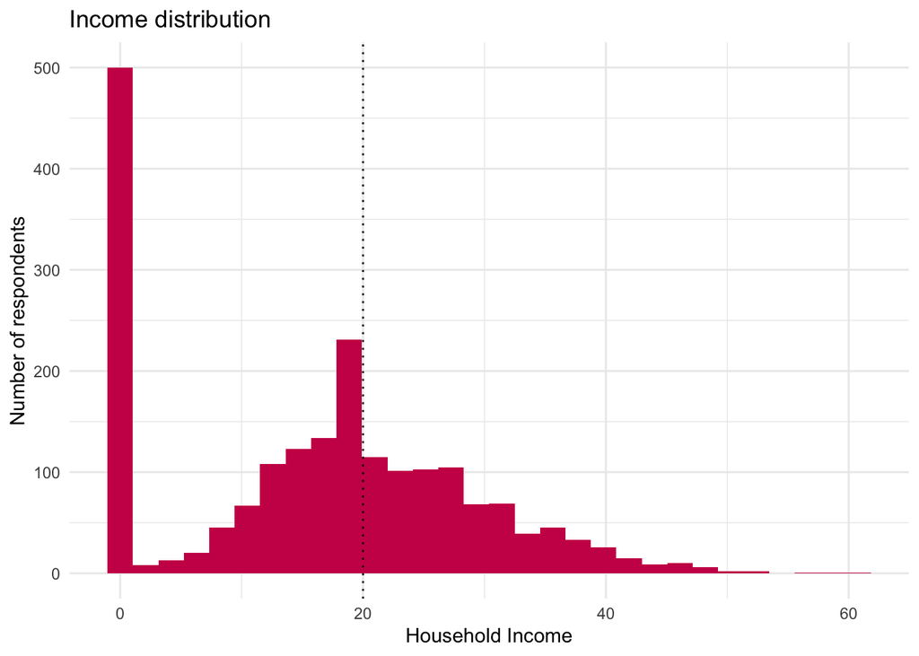

```r
ggplot(hospitals,
       aes(x = incomeR)) +
  geom_histogram(fill = "#cc0055") +
  labs(title = "Income distribution",
       x = "Household Income",
       y = "Number of respondents") +
  geom_vline(xintercept = 20, linetype = "dotted") +
  theme_minimal()
```

```r
hospitals %>%
  dplyr::filter(dplyr::between(incomeR, 19, 21)) %>% #filter values between 19000 and 21000
  dplyr::group_by(program) %>%
  dplyr::summarize(n = n()) %>%
  knitr::kable() %>%
  kableExtra::kable_styling()
```

| program | n |
| --- | --- |
| 0 | 48 |
| 1 | 168 |

```r
binom.test(48, 216, p = 0.5)
```

```
    Exact binomial test

data:  48 and 216
number of successes = 48, number of trials = 216, p-value < 2.2e-16
alternative hypothesis: true probability of success is not equal to 0.5
95 percent confidence interval:
 0.1686283 0.2836092
sample estimates:
probability of success
             0.2222222
```

The histogram shows that there could be a possibility that people where trying to sort it out just before the cut-off as your colleague points out. To clarify these the result of the binomial test prove that indeed the observed distribution do deviate from expected distribution of observations into the two categories , so the units just around the threshold doesn´t end up on either group by chance. In other words, there is evidence of sorting because the p-value is less than 0.05.

8. Another colleague points out to you that several other government programs (including food stamps, etc.) have the same income threshold for eligibility. How might this knowledge impact your interpretation of your results? [1 point]

The statement of the colleague validate the results of part g) because due to the amount of government programs and potential benefits people are sorting themselves before the household income cut-off to become beneficiaries of these programs.

### Task 3 - Statistics inspired meme [1 bonus percentage point]

Create a stats-inspired meme using `memer` (or any other R meme dedicated package) to earn one bonus percentage point. The meme should be related to one of the topics covered in the sessions this assignment is based on.

[figure not shown]

```r
library (meme)
angry_mem <- system.file("angry8.jpg", package="meme")
ac<- meme(angry_mem, "Instrument is valid but weak", "R-frustation")

ac + list(upper = "Instrument is valid but weak",
        lower = "R-frustation", font = "Courier", size=2)
```